# Predicting the way barbel lifts were performed by 6 persons

Peter Knapen

09/19/2015

# Summary

Using devices such as Jawbone Up, Nike FuelBand, and Fitbit it is now possible to collect a large amount of data about personal activity relatively inexpensively. These type of devices are part of the quantified self movement – a group of enthusiasts who take measurements about themselves regularly to improve their health, to find patterns in their behavior, or because they are tech geeks. One thing that people regularly do is quantify how much of a particular activity they do, but they rarely quantify how well they do it.  
In this project, our goal will be to use data from accelerometers on the belt, forearm, arm and dumbbell of 6 participants in order to predict whether an excercise is performed correctly or not. The participants were asked to perform barbell lifts correctly and incorrectly in 5 different ways. More information is available from the website here: http://groupware.les.inf.puc-rio.br/har (see the section on the Weight Lifting Exercise Dataset).  
As only a subset of the data was provided, the way the exercise was performed should be predicted from this reduced set.  
First the data was reduced from 160 to 60 variables by removing columns with Na and NAN’s, which mostly were calculated by Vellosso $et \ all$.  
Next with randomForest the complete model was analysed. Based on cross validation 13 variables were selected to build the second model. It is shown that this reduction in data does not increase the out of sample error much.

# Introduction

The training data for this project are available here:  
https://d396qusza40orc.cloudfront.net/predmachlearn/pml-training.csv.  
The test data are available here:  
https://d396qusza40orc.cloudfront.net/predmachlearn/pml-testing.csv.  
The data for this project come from this source: http://groupware.les.inf.puc-rio.br/har.  
Vellosso $et \ all$ describe in their document that they want to predict whether lifting a dumbbell is done correctly or not. For this purpose 6 persons have performed 10 repetitions of correct lifting and of 4 defined mistakes, while measuring the accelerations, Euler angels and magnetic field disturbances with 4 transducers, mounted on the belt, the fore arm and arm. They post-processed this data and calculated an additional set of variables, like kurtosis, skewness, amplitude, mean, std, min and max and got the best predictions by selecting a subset when a 2.5 second time window was used with an overlap of 0.5 seconds.  
The goal of this project is to predict the manner in which these 6 persons did the exercise. This is the “classe” variable in the training set.

# Retrieving and pre-processing data

The data is downloaded from the above mentioned sources. The original data is loaded directly from the website

```r
require(downloader)
require(curl)
require(doMC)
require(caret)
require(ggplot2)
require(dplyr)
require(GGally)
require(knitr)
#require(printr)
set.seed(12345)
if(!file.exists("pml-training.csv")){
url1<-"https://d396qusza40orc.cloudfront.net/predmachlearn/pml-training.csv"
download.file(url1,"~/Coursera/Practical_machine_learning/course_project/pml-training.csv", method="curl")
}
training<-read.table("pml-training.csv", header=TRUE, sep=c(","),na.strings = c("NA", "#DIV/0!", ""))
training2 <- training[,colSums(is.na(training)) == 0]
str(training)
training3<-read.table("WearableComputing_weight_lifting_exercises_biceps_curl_variations.csv", header=TRUE, sep=",")

training4<-filter(training3,new_window=="yes")
if(!file.exists("pml-testing.csv")){
url1<-"https://d396qusza40orc.cloudfront.net/predmachlearn/pml-testing.csv"
download.file(url1,"~/Coursera/Practical_machine_learning/course_project/pml-testing.csv", method="curl")
}
testing<-read.table("pml-testing.csv", header=TRUE, sep=",",na.strings = c("NA", "#DIV/0!", ""))
testing2 <- testing[,colSums(is.na(testing)) == 0]
str(testing)
training2$classe<-as.factor(training2$classe)
```

By omitting the columns with NA, NaN (#DIV/0!) and empty fields, we can reduce the number of variables from 160 to 60. As testing2 shows no column for classe, we will split the training set into a new training and testing set for training and testing purposes. The first 7 variables are not prediction variables, but used by Vellosso $et \ all$ in order to calculate their 97 derived variables.

```r
inTrain <- createDataPartition(y=training2$classe,
                              p=0.8, list=FALSE)
training5 <- training2[inTrain,]
M <- abs(cor(training5[,-c(1:7,60)]))
diag(M) <- 0
which(M > 0.8,arr.ind=T)
testing5 <- training2[-inTrain,]
```

It turns out the 60 signals 38 have a correlation of more than 80%. I did not leave out these columns, as this could cause bias in the outcome. Due to kinematic joints in the body (eg. shoulder,elbow, wrist), a lot of these signals can be correlated.

# Building the randomForest model.

Model 1 is calculated with all remaining 52 predictors, using parallel processing. With 16GB and 8 cores (Intel® Core™ i7-4900MQ CPU @ 2.80GHz × 8 ), it took 20 minutes to calculate.

```r
registerDoMC(cores=8)
name1<-names(training5)
model1<-train(classe~.-X -user_name -raw_timestamp_part_1 -raw_timestamp_part_2 -cvtd_timestamp -new_window -num_window, method="rf",data=training5)
```

The most important predictors can be calculated by using the function varImp from the carret package. Predictions can be calculated using the training-set.

```r
mostImp<-varImp(model1)
predict1<-predict(model1,newdata=training5)
C1 <- confusionMatrix(training5$classe, predict1)
insample1<-(1-C1$overall[[1]])*100
```

The 20 most important variables are:

```r
mostImp
```

```
## rf variable importance
##
##   only 20 most important variables shown (out of 52)
##
##                   Overall
## roll_belt          100.00
## yaw_belt            79.05
## magnet_dumbbell_z   69.30
## magnet_dumbbell_y   64.97
## pitch_belt          64.47
## pitch_forearm       58.92
## roll_forearm        52.82
## magnet_dumbbell_x   51.95
## accel_belt_z        47.01
## magnet_belt_y       45.34
## accel_dumbbell_y    45.08
## roll_dumbbell       44.82
## magnet_belt_z       43.45
## accel_dumbbell_z    39.18
## roll_arm            37.57
## accel_forearm_x     32.29
## accel_dumbbell_x    31.42
## yaw_dumbbell        30.19
## gyros_belt_z        29.85
## magnet_arm_x        28.90
```

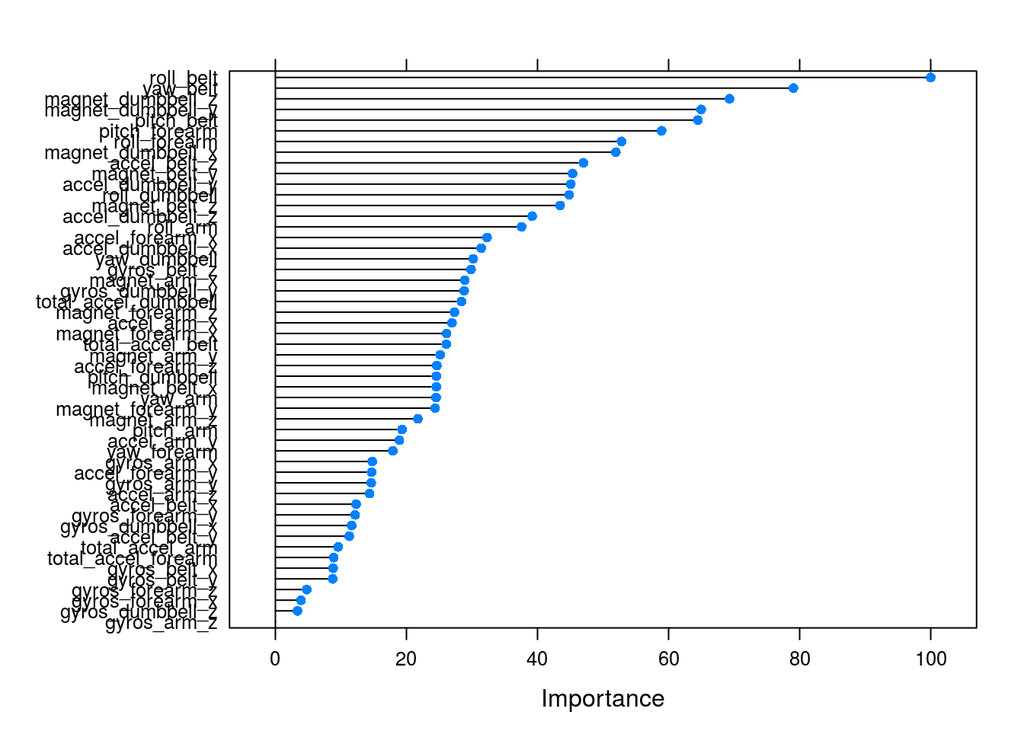

```r
plot(mostImp)
```

From the confusionMatrix the in-sample error can be calculated as 1-accuracy, in this case 0.13 percent. The out of sample will be larger, as this is based on the confusion matrix where predictions are compared to the test set. This will be done later on. Now use cross validation to determine the expected error when reducing the number of variables taken into the model.

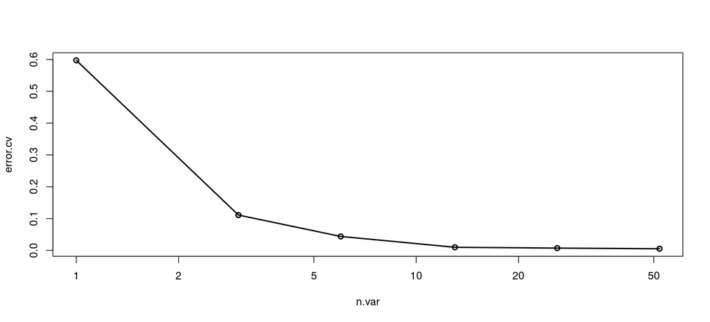

```r
result<-rfcv(training5[8:59], training5[,60], cv.fold=5)
with(result, plot(n.var, error.cv, log="x", type="o", lwd=2))
```

From the plot above, it can be seen that the error drops significantly till 13 variables are used.

```r
mostImp2<-mostImp$importance %>%
         mutate(ind=c(1:length(Overall))) %>%
         filter(Overall >20)
mostImp3<-mostImp2[with(mostImp2,order(-Overall,-ind)),]
index<-mostImp3$ind
#mostImp3
```

Model2 is built using these 13 variables.

```r
# I could not get the colums selected, without reducing the data frame, so I put in the columns manually
registerDoMC(cores=8)
model2<-train(classe~+roll_belt + yaw_belt +magnet_dumbbell_z + magnet_dumbbell_y + pitch_forearm + pitch_belt + magnet_dumbbell_x + roll_forearm + magnet_belt_z + roll_dumbbell + accel_dumbbell_y + accel_belt_z +magnet_belt_y, method="rf",data=training5)
```

With model2 we can predict classe and calculate a new confusionMatrix based on the trainings set.

```r
predict2<-predict(model2,newdata=training5)
C2 <- confusionMatrix(training5$classe, predict2)
insample2<-(1-C2$overall[[1]])*100
```

The in-sample error can also be calculated for this model: 0 percent, which is smaller than the one for the complete model (model1)

# Predictions for the testing set

With model1 ( the complete model), predictions for the testing data and its confusion matrix can be calculated:

```r
predict3<-predict(model1,newdata=testing5)
C3 <- confusionMatrix(testing5$classe, predict3)
outsample1<-(1-C3$overall[[1]])*100
C3
```

```
## Confusion Matrix and Statistics
##
##           Reference
## Prediction    A    B    C    D    E
##          A 1116    0    0    0    0
##          B    4  755    0    0    0
##          C    0    5  679    0    0
##          D    0    0    6  637    0
##          E    0    0    0    0  721
##
## Overall Statistics
##
##                Accuracy : 0.9962
##                  95% CI : (0.9937, 0.9979)
##     No Information Rate : 0.2855
##     P-Value [Acc > NIR] : < 2.2e-16
##
##                   Kappa : 0.9952
##  Mcnemar's Test P-Value : NA
##
## Statistics by Class:
##
##                      Class: A Class: B Class: C Class: D Class: E
## Sensitivity            0.9964   0.9934   0.9912   1.0000   1.0000
## Specificity            1.0000   0.9987   0.9985   0.9982   1.0000
## Pos Pred Value         1.0000   0.9947   0.9927   0.9907   1.0000
## Neg Pred Value         0.9986   0.9984   0.9981   1.0000   1.0000
## Prevalence             0.2855   0.1937   0.1746   0.1624   0.1838
## Detection Rate         0.2845   0.1925   0.1731   0.1624   0.1838
## Detection Prevalence   0.2845   0.1935   0.1744   0.1639   0.1838
## Balanced Accuracy      0.9982   0.9961   0.9948   0.9991   1.0000
```

The out of sample error for model1 is 0.38 percent  
The same can be done for model 2, resulting in:

```r
predict4<-predict(model2,newdata=testing5)
C4 <- confusionMatrix(testing5$classe, predict4)
outsample2<-(1-C4$overall[[1]])*100
C4
```

```
## Confusion Matrix and Statistics
##
##           Reference
## Prediction    A    B    C    D    E
##          A 1112    4    0    0    0
##          B    5  744    6    4    0
##          C    0    9  673    2    0
##          D    0    0    6  635    2
##          E    0    1    1    3  716
##
## Overall Statistics
##
##                Accuracy : 0.989
##                  95% CI : (0.9853, 0.9921)
##     No Information Rate : 0.2847
##     P-Value [Acc > NIR] : < 2.2e-16
##
##                   Kappa : 0.9861
##  Mcnemar's Test P-Value : NA
##
## Statistics by Class:
##
##                      Class: A Class: B Class: C Class: D Class: E
## Sensitivity            0.9955   0.9815   0.9810   0.9860   0.9972
## Specificity            0.9986   0.9953   0.9966   0.9976   0.9984
## Pos Pred Value         0.9964   0.9802   0.9839   0.9876   0.9931
## Neg Pred Value         0.9982   0.9956   0.9960   0.9973   0.9994
## Prevalence             0.2847   0.1932   0.1749   0.1642   0.1830
## Detection Rate         0.2835   0.1897   0.1716   0.1619   0.1825
## Detection Prevalence   0.2845   0.1935   0.1744   0.1639   0.1838
## Balanced Accuracy      0.9970   0.9884   0.9888   0.9918   0.9978
```

The outof sample error is 1.1 percent, somewhat higher than the one for model 1, but still small.  
Based on model2, the predictions can be calculated for the testing data from testing2, which are needed for part 2 of the assignment:

```r
predict5<-predict(model2,newdata=testing2)
answer<-as.character(predict5)
```

B, A, B, A, A, E, D, B, A, A, B, C, B, A, E, E, A, B, B, B

# Conclusions

We have constructed a model based on 13 out of 52 predictor variables, which gave an out-sample error of less than 2 percent. When we tested this with the original test data we got a score of 100 percent, so the samples in the testing data were not that close to the borders of the classe variables as was in the self constructed testing set.

# Appendix

From the original 160 variables in the original data, only 52 variables are used for building model1: roll_belt, pitch_belt, yaw_belt, total_accel_belt, gyros_belt_x, gyros_belt_y, gyros_belt_z, accel_belt_x, accel_belt_y, accel_belt_z, magnet_belt_x, magnet_belt_y, magnet_belt_z, roll_arm, pitch_arm, yaw_arm, total_accel_arm, gyros_arm_x, gyros_arm_y, gyros_arm_z, accel_arm_x, accel_arm_y, accel_arm_z, magnet_arm_x, magnet_arm_y, magnet_arm_z, roll_dumbbell, pitch_dumbbell, yaw_dumbbell, total_accel_dumbbell, gyros_dumbbell_x, gyros_dumbbell_y, gyros_dumbbell_z, accel_dumbbell_x, accel_dumbbell_y, accel_dumbbell_z, magnet_dumbbell_x, magnet_dumbbell_y, magnet_dumbbell_z, roll_forearm, pitch_forearm, yaw_forearm, total_accel_forearm, gyros_forearm_x, gyros_forearm_y, gyros_forearm_z, accel_forearm_x, accel_forearm_y, accel_forearm_z, magnet_forearm_x, magnet_forearm_y, magnet_forearm_z  
classe is a variable with 5 levels:  
- A: correct performed  
- B: throwing the elbows to the front  
- C: lifting the dumbbell only halfway  
- D: lowering the dumbbell only halfway  
- E: throwing the hips to the front.

```r
pml_write_files = function(x){
  n = length(x)
  for(i in 1:n){
    filename = paste0("problem_id_",i,".txt")
    write.table(x[i],file=filename,quote=FALSE,row.names=FALSE,col.names=FALSE)
  }
}
pml_write_files(answer)
```